# Estudio estadístico de la calidad del agua y aire

Cristina Suárez

## Creación de muestras

En este apartado vamos a crear muestras de datos a partir de un fichero CSV.

Lo primero que vamos a hacer es cargar el fichero CSV.

```r
#Cargamos el fichero CSV
df <- read.csv("cities_air_quality_water_pollution.csv")
head(df)
```

```
              City                Region                   Country AirQuality
1    New York City              New York  United States of America   46.81604
2 Washington, D.C.  District of Columbia  United States of America   66.12903
3    San Francisco            California  United States of America   60.51402
4           Berlin                                         Germany   62.36413
5      Los Angeles            California  United States of America   36.62162
6             Bern        Canton of Bern               Switzerland   94.31818
  WaterPollution
1       49.50495
2       49.10714
3       43.00000
4       28.61272
5       61.29944
6       12.50000
```

Una vez cargado el fichero, vamos a crear una muestra de 100 datos.

```r
library(dplyr)
library(ggplot2)

# creamos la primera muestra de 100 datos
muestra1 <- df %>% sample_n(100)
head(muestra1)
```

```
         City                 Region                   Country AirQuality
1    Ensenada        Baja California                    Mexico   79.41176
2    La Plata  Buenos Aires Province                 Argentina   40.90909
3     Passaic             New Jersey  United States of America   50.00000
4  Santa Rosa               La Pampa                 Argentina   75.00000
5 Fuenlabrada    Community of Madrid                     Spain   87.50000
6 Tarlac City                                      Philippines   56.25000
  WaterPollution
1       50.00000
2       63.63636
3       75.00000
4       75.00000
5      100.00000
6       75.00000
```

```r
# Agrupamos los datos por país
muestra1 <- muestra1 %>% group_by(Country)
head(muestra1)
```

```
# A tibble: 6 × 5
# Groups:   Country [5]
  City        Region                   Country                   AirQu…¹ Water…²
  <chr>       <chr>                    <chr>                       <dbl>   <dbl>
1 Ensenada    " Baja California"       " Mexico"                    79.4    50
2 La Plata    " Buenos Aires Province" " Argentina"                 40.9    63.6
3 Passaic     " New Jersey"            " United States of Ameri…    50      75
4 Santa Rosa  " La Pampa"              " Argentina"                 75      75
5 Fuenlabrada " Community of Madrid"   " Spain"                     87.5   100
6 Tarlac City " "                      " Philippines"               56.2    75
# … with abbreviated variable names ¹AirQuality, ²WaterPollution
```

Y ahora vamos a crear otra muestra de 100 datos.

```r
#Creamos otra muestra de 100 datos
muestra2 <- sample_n(df, 100)
head(muestra2)
```

```
         City                Region                     Country AirQuality
1   Masterton     Wellington Region                 New Zealand   85.71429
2     Livorno               Tuscany                       Italy   55.55556
3  Wafangdian              Liaoning  People's Republic of China    0.00000
4 Santa Marta  Magdalena Department                    Colombia   50.00000
5        Kish    Hormozgan Province                        Iran  100.00000
6      Dalian              Liaoning  People's Republic of China   26.78571
  WaterPollution
1       33.33333
2       62.50000
3       50.00000
4       71.42857
5        0.00000
6       50.00000
```

```r
# Agrupamos los datos por país
muestra2 <- muestra2 %>% group_by(Country)
head(muestra2)
```

```
# A tibble: 6 × 5
# Groups:   Country [5]
  City        Region                  Country                    AirQu…¹ Water…²
  <chr>       <chr>                   <chr>                        <dbl>   <dbl>
1 Masterton   " Wellington Region"    " New Zealand"                85.7    33.3
2 Livorno     " Tuscany"              " Italy"                      55.6    62.5
3 Wafangdian  " Liaoning"             " People's Republic of Ch…     0      50
4 Santa Marta " Magdalena Department" " Colombia"                   50      71.4
5 Kish        " Hormozgan Province"   " Iran"                      100       0
6 Dalian      " Liaoning"             " People's Republic of Ch…    26.8    50
# … with abbreviated variable names ¹AirQuality, ²WaterPollution
```

Para el test de Levene vamos a necesitar tres muestras, por lo que creamos una tercera.

```r
muestra3 <- df %>% sample_n(100)
head(muestra3)
```

```
       City                Region                   Country AirQuality
1  Jamnagar               Gujarat                     India  34.482759
2   Clayton              Missouri  United States of America  87.500000
3 Ghaziabad         Uttar Pradesh                     India  12.903226
4 Boa Vista               Roraima                    Brazil  91.666667
5     Mainz  Rhineland-Palatinate                   Germany  86.111111
6  Sanandaj    Kurdistan Province                      Iran   3.571429
  WaterPollution
1       58.33333
2       50.00000
3       80.00000
4       58.33333
5       35.00000
6       83.33333
```

```r
# Agrupamos los datos por país
muestra3 <- muestra3 %>% group_by(Country)
head(muestra3)
```

```
# A tibble: 6 × 5
# Groups:   Country [5]
  City      Region                  Country                     AirQua…¹ Water…²
  <chr>     <chr>                   <chr>                          <dbl>   <dbl>
1 Jamnagar  " Gujarat"              " India"                       34.5     58.3
2 Clayton   " Missouri"             " United States of America"    87.5     50
3 Ghaziabad " Uttar Pradesh"        " India"                       12.9     80
4 Boa Vista " Roraima"              " Brazil"                      91.7     58.3
5 Mainz     " Rhineland-Palatinate" " Germany"                     86.1     35
6 Sanandaj  " Kurdistan Province"   " Iran"                         3.57    83.3
# … with abbreviated variable names ¹AirQuality, ²WaterPollution
```

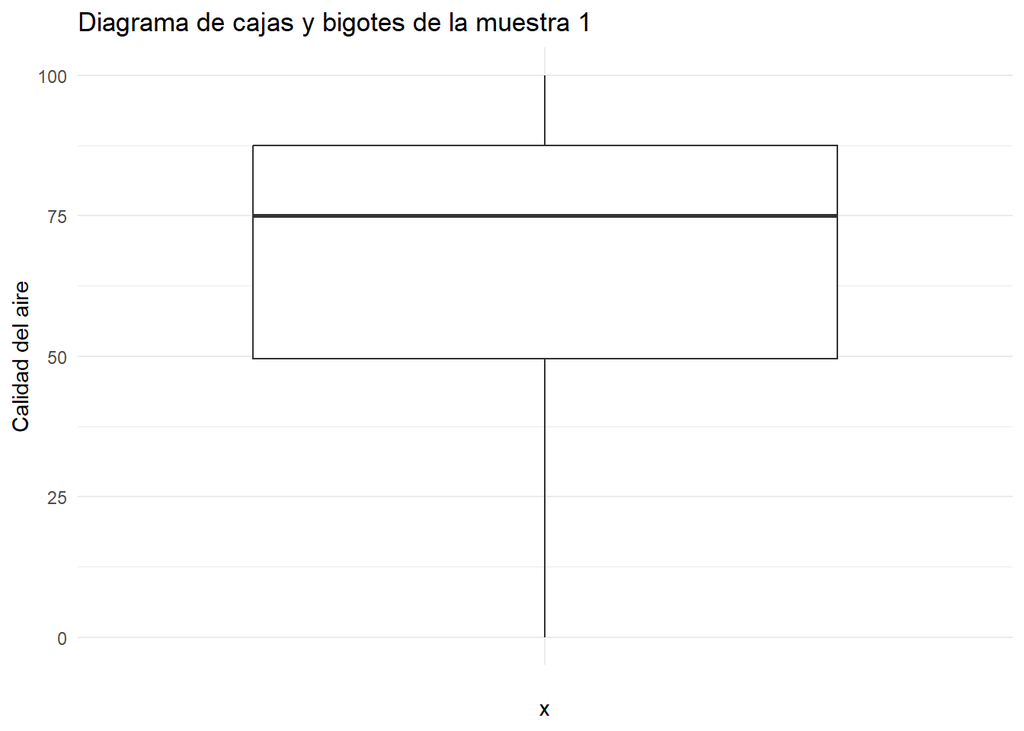

```r
#Diagrama de cajas y bigotes de la muestra 1 calidad del aire
ggplot(muestra1, aes(x = "", y = AirQuality)) +
  geom_boxplot() +
  labs(title = "Diagrama de cajas y bigotes de la muestra 1", y = "Calidad del aire") +
  theme_minimal()
```

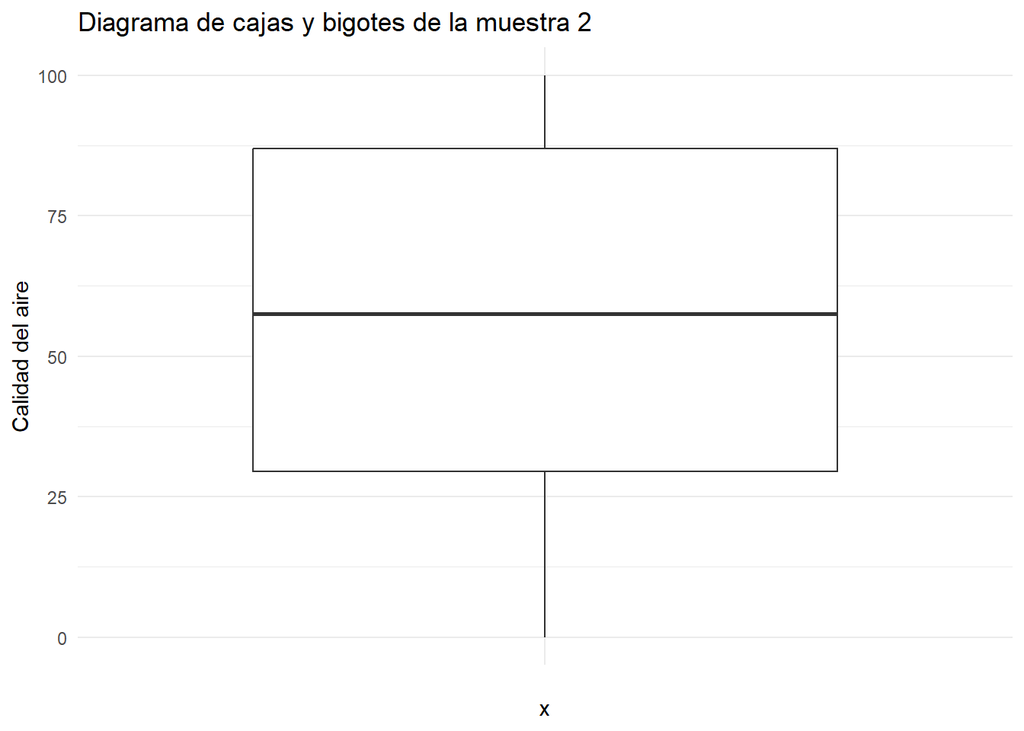

```r
#Diagrama de cajas y bigotes de la muestra 2 calidad del aire
ggplot(muestra2, aes(x = "", y = AirQuality)) +
  geom_boxplot() +
  labs(title = "Diagrama de cajas y bigotes de la muestra 2", y = "Calidad del aire") +
  theme_minimal()
```

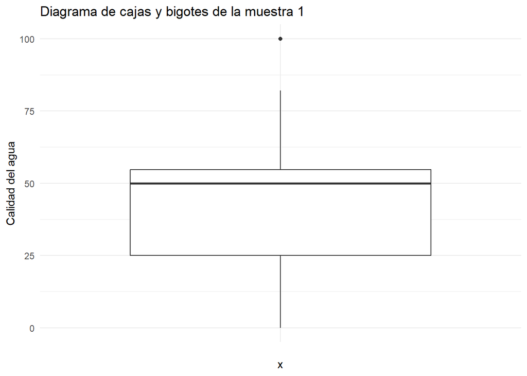

```r
#Diagrama de cajas y bigotes de la muestra 1 calidad del agua
ggplot(muestra1, aes(x = "", y = WaterPollution)) +
  geom_boxplot() +
  labs(title = "Diagrama de cajas y bigotes de la muestra 1", y = "Calidad del agua") +
  theme_minimal()
```

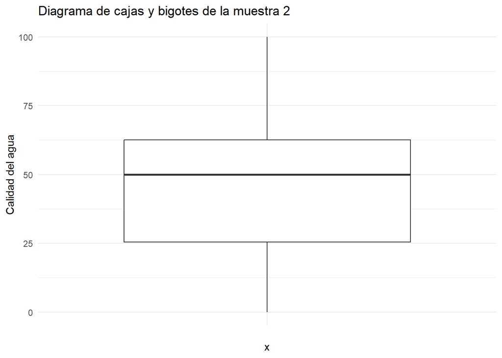

```r
#Diagrama de cajas y bigotes de la muestra 2 calidad del agua
ggplot(muestra2, aes(x = "", y = WaterPollution)) +
  geom_boxplot() +
  labs(title = "Diagrama de cajas y bigotes de la muestra 2", y = "Calidad del agua") +
  theme_minimal()
```

En caso de observarse algun dato atípico, no lo vamos a eliminar, por ser tan próximo al resto de datos.

## Estimación puntual de las medias y cuasivarianzas muestrales. Análisis de los resultados.

En este apartado vamos a calcular la media y la cuasivarianza muestral de las dos muestras creadas anteriormente.

Para calcular la media muestral de la primera muestra, vamos a utilizar la función mean().

```r
#Calculamos la media muestral de las muestras respecto de la calidad del aire
media1a <- mean(muestra1$AirQuality)
media1a
```

```
[1] 66.52265
```

```r
media2a <- mean(muestra2$AirQuality)
media2a
```

```
[1] 57.18144
```

La calidad del aire media de la primera muestra es 66.5226472, mientras que la media de la segunda muestra es 57.1814409.

La media sin embargo de la calidad del agua de las muestras es:

```r
#Calculamos la media muestral de las muestras respecto de la calidad del agua
media1w <- mean(muestra1$WaterPollution)
media1w
```

```
[1] 43.389
```

```r
media2w <- mean(muestra2$WaterPollution)
media2w
```

```
[1] 46.06781
```

La calidad del agua media de la primera muestra es 43.389001, mientras que la media de la segunda muestra es 46.067812.

```r
n1 <- length(muestra1$AirQuality)
n2 <- length(muestra2$AirQuality)

#Calculamos la cuasivarianza muestral de las muestras respecto de la calidad del aire
cuasivarianza1a <- sum((muestra1$AirQuality - media1a)^2) / (n1 - 1)
cuasivarianza1a
```

```
[1] 820.0064
```

```r
cuasivarianza2a <- sum((muestra2$AirQuality - media2a)^2) / (n2 - 1)
cuasivarianza2a
```

```
[1] 1033.125
```

```r
#Calculamos la cuasivarianza muestral de las muestras respecto de la calidad del agua
cuasivarianza1w <- sum((muestra1$WaterPollution - media1w)^2) / (n1 - 1)
cuasivarianza1w
```

```
[1] 695.1501
```

```r
cuasivarianza2w <- sum((muestra1$WaterPollution - media2w)^2) / (n2 - 1)
cuasivarianza2w
```

```
[1] 702.3986
```

Y las respectivas cuasidesviaciones típicas son:

```r
#Calculamos la cuasidesviación típica muestral de las muestras respecto de la calidad del aire
cuasidesviacion1a <- sqrt(cuasivarianza1a)
cuasidesviacion1a
```

```
[1] 28.63575
```

```r
cuasidesviacion2a <- sqrt(cuasivarianza2a)
cuasidesviacion2a
```

```
[1] 32.14226
```

```r
#Calculamos la cuasidesviación típica muestral de las muestras respecto de la calidad del agua
cuasidesviacion1w <- sqrt(cuasivarianza1w)
cuasidesviacion1w
```

```
[1] 26.3657
```

```r
cuasidesviacion2w <- sqrt(cuasivarianza2w)
cuasidesviacion2w
```

```
[1] 26.5028
```

```r
# Creamos un data frame con los valores de las cuasivarianzas y de las medias
df <- data.frame(c("Muestra 1", "Muestra 2"), c(cuasivarianza1a, cuasivarianza2a), c(cuasivarianza1w, cuasivarianza2w), c(media1a, media2a), c(media1w, media2w))
colnames(df) <- c("Muestra", "Cuasivarianza aire", "Cuasivarianza agua", "Media aire", "Media agua")
df
```

```
    Muestra Cuasivarianza aire Cuasivarianza agua Media aire Media agua
1 Muestra 1           820.0064           695.1501   66.52265   43.38900
2 Muestra 2          1033.1250           702.3986   57.18144   46.06781
```

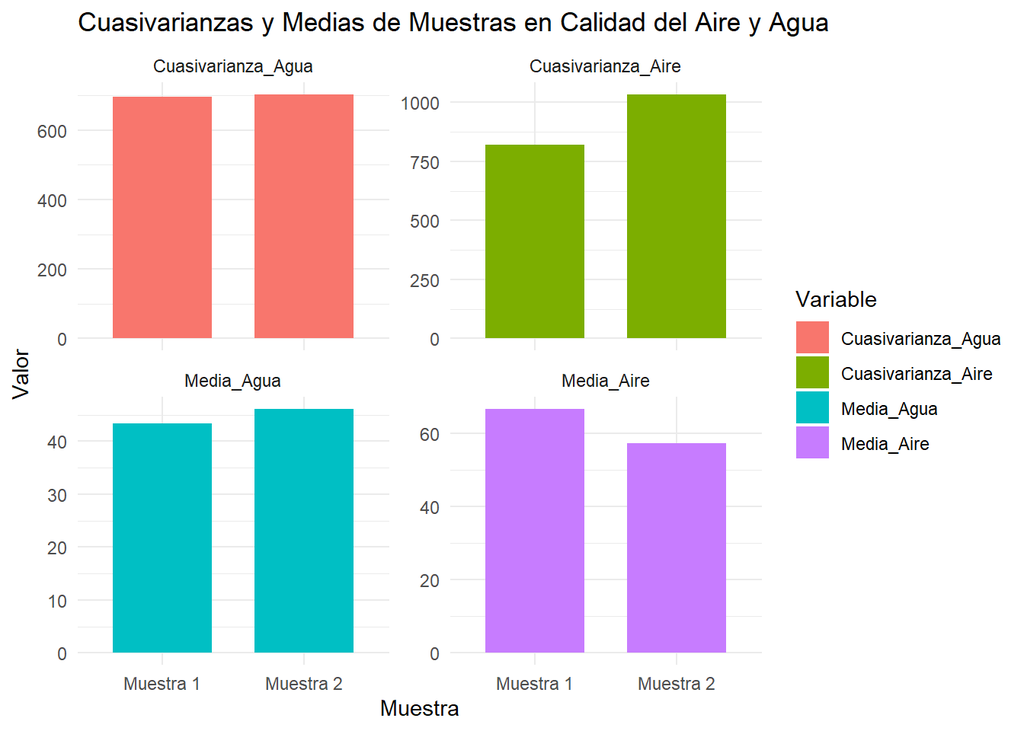

```r
# Organizamos el dataframe con los valores de cuasivarianzas y medias
df <- data.frame(
  Muestra = c("Muestra 1", "Muestra 2"),
  Cuasivarianza_Aire = c(cuasivarianza1a, cuasivarianza2a),
  Cuasivarianza_Agua = c(cuasivarianza1w, cuasivarianza2w),
  Media_Aire = c(media1a, media2a),
  Media_Agua = c(media1w, media2w)
)

# Convertimos el dataframe a formato largo (tidy)
df_long <- tidyr::gather(df, "Variable", "Valor", -Muestra)

# Gráfico de barras
ggplot(df_long, aes(x = Muestra, y = Valor, fill = Variable)) +
  geom_bar(stat = "identity", position = "dodge", width = 0.7) +
  labs(title = "Cuasivarianzas y Medias de Muestras en Calidad del Aire y Agua", y = "Valor") +
  facet_wrap(~Variable, scales = "free_y") +
  theme_minimal()
```

Conclusión General:

Al analizar los resultados obtenidos, se observa variabilidad entre las muestras en términos de cuasivarianzas y medias tanto en la calidad del aire como en la calidad del agua. Estas diferencias sugieren la presencia de factores ambientales o geográficos que impactan de manera diversa en cada variable medida.

La cuasivarianza más alta en una muestra indica una mayor dispersión de datos y posiblemente condiciones ambientales más variables o mediciones más amplias. Por otro lado, una media más alta puede indicar una mejor calidad promedio en la variable analizada.

Es crucial destacar que estas interpretaciones son específicas para cada variable, y las conclusiones pueden variar según la naturaleza de los datos. La evaluación individual de cada métrica proporciona una comprensión más completa de las diferencias entre las muestras, subrayando la importancia de analizar cada variable por separado.

En resumen, la diversidad en los resultados destaca la complejidad y singularidad de cada conjunto de datos. Estos hallazgos resaltan la necesidad de un enfoque contextualizado al interpretar resultados y subrayan la importancia de considerar factores específicos de cada variable para una comprensión completa y precisa.

## Estimación de los intervalos de confianza de las medias y cuasivarianzas muestrales. Análisis de los resultados.

Estimación por intervalos de confianza al 95% de las medias poblacionales, varianzas poblacionales, diferencia de medias poblacionales y cociente de varianzas poblacionales. Análisis de los resultados.

Primero tenemos que establecer alfa como 0.05.

```r
alpha <- 0.05
```

### Intervalos de confianza de las medias poblacionales

He creados una función genérica para calcular los intervalos de confianza de la media poblacional, que es:

```r
ICT <- function(n, s1, alpha, media){
  t0 <- qt(0.025, df = n - 1, lower.tail = FALSE)
  ICM <- c(media - t0 * s1 / sqrt(n), media + t0 * s1 / sqrt(n))
  ICM <- round(ICM, 3)
  return(ICM)
}
```

Y ahora vamos a calcular los intervalos de confianza de las medias poblacionales de las dos muestras.

```r
n1 <- length(muestra1$AirQuality)
s1 <- sd(muestra1$AirQuality)
ICT(n1, s1, alpha, media1a)
```

```
[1] 60.841 72.205
```

```r
print(paste0("intervalo de confianza para la media poblacional de la calidad del aire de la muestra 1 es: (", ICT(n1, s1, alpha, media1a)[1], ", ", ICT(n1, s1, alpha, media1a)[2], ")"))
```

```
[1] "intervalo de confianza para la media poblacional de la calidad del aire de la muestra 1 es: (60.841, 72.205)"
```

```r
ICT(n2, cuasivarianza2a, alpha, media2a)
```

```
[1] -147.813  262.176
```

```r
print(paste0("intervalo de confianza para la media poblacional de la calidad del aire de la muestra 2 es: (", ICT(n2, cuasivarianza2a, alpha, media2a)[1], ", ", ICT(n2, cuasivarianza2a, alpha, media2a)[2], ")"))
```

```
[1] "intervalo de confianza para la media poblacional de la calidad del aire de la muestra 2 es: (-147.813, 262.176)"
```

```r
ICT(n1, cuasivarianza1w, alpha, media1w)
```

```
[1] -94.544 181.322
```

```r
print(paste0("intervalo de confianza para la media poblacional de la calidad del agua de la muestra 1 es: (", ICT(n1, cuasivarianza1w, alpha, media1w)[1], ", ", ICT(n1, cuasivarianza1w, alpha, media1w)[2], ")"))
```

```
[1] "intervalo de confianza para la media poblacional de la calidad del agua de la muestra 1 es: (-94.544, 181.322)"
```

```r
ICT(n2, cuasivarianza2w, alpha, media2w)
```

```
[1] -93.303 185.439
```

```r
print(paste0("intervalo de confianza para la media poblacional de la calidad del agua de la muestra 2 es: (", ICT(n2, cuasivarianza2w, alpha, media2w)[1], ", ", ICT(n2, cuasivarianza2w, alpha, media2w)[2], ")"))
```

```
[1] "intervalo de confianza para la media poblacional de la calidad del agua de la muestra 2 es: (-93.303, 185.439)"
```

### Intervalos de confianza de las varianzas poblacionales

Genero la función para calcular los intervalos de confianza de la varianza poblacional, que es:

```r
#intervalo de confianza para la varianza poblacional
ICV <- function(n, s1, alpha){
  k2 <- qchisq(alpha/2, df = n - 1, lower.tail = FALSE)
  k1 <- qchisq(1-alpha/2, df = n - 1, lower.tail = FALSE)
  ICC <- c((n-1)*s1^2/k1, (n-1)*s1^2/k2)
  ICC <- round(ICC, 3)
  return(ICC)
}
```

[output not shown]

[output not shown]

[output not shown]

[output not shown]

[output not shown]

[output not shown]

[output not shown]

[output not shown]

### Intervalos de confianza de las diferencias de medias poblacionales

Genero la función para calcular los intervalos de confianza de la diferencia de medias poblacionales, que es:

```r
#intervalo de confianza para la diferencia de medias poblacionales
#intervalo de confianza para la diferencia de medias poblacionales de la calidad del agua
IDM <- function(n1, n2, s1, s2, alpha){
    t0 <- qt(0.025, df = n1 + n2 - 2, lower.tail = FALSE)
    ICD <- c(media1a-media2a - t0 * sqrt(s1^2/n1 + s2^2/n2), media1a-media2a + t0 * sqrt(s1^2/n1 + s2^2/n2))
    ICD <- round(ICD, 3)
}
```

[output not shown]

[output not shown]

### Intervalos de confianza de el cociente de varianzas poblacionales

Ahora genero la función para calcular los intervalos de confianza del cociente de varianzas poblacionales, que es:

```r
ICVs <- function(n1, n2, s1, s2, alpha){
    F0 <- qf(0.025, df1 = n1 - 1, df2 = n2 - 1, lower.tail = FALSE)
    ICF <- c((s1^2/s2^2)/F0, (s1^2/s2^2)*F0)
    ICF <- round(ICF, 3)

    # Comprueba si el intervalo de confianza incluye el valor 1
    if (ICF[1] <= 1 && ICF[2] >= 1) {
        message <- "Las varianzas son iguales. El 1 está contenido en el intervalo."
    } else {
        message <- "Las varianzas no son iguales. El 1 no está contenido en el intervalo."
    }

    return(list(ICF = ICF, message = message))
}

# Calidad del aire
result_aire <- ICVs(n1, n2, cuasivarianza1a, cuasivarianza2a, 0.05)
print(paste0("Intervalo de confianza para el cociente de varianzas poblacionales de la calidad del aire es: (", result_aire$ICF[1], ", ", result_aire$ICF[2], ")"))
```

```
[1] "Intervalo de confianza para el cociente de varianzas poblacionales de la calidad del aire es: (0.424, 0.936)"
```

```r
print(result_aire$message)
```

```
[1] "Las varianzas no son iguales. El 1 no está contenido en el intervalo."
```

```r
# Calidad del agua
result_agua <- ICVs(n1, n2, cuasivarianza1w, cuasivarianza2w, 0.05)
print(paste0("Intervalo de confianza para el cociente de varianzas poblacionales de la calidad del agua es: (", result_agua$ICF[1], ", ", result_agua$ICF[2], ")"))
```

```
[1] "Intervalo de confianza para el cociente de varianzas poblacionales de la calidad del agua es: (0.659, 1.456)"
```

```r
print(result_agua$message)
```

```
[1] "Las varianzas son iguales. El 1 está contenido en el intervalo."
```

## Contraste de hipótesis sobre las medias y varianzas poblacionales. Análisis de los resultados.

En este apartado vamos a realizar un contraste de hipótesis sobre las medias y varianzas poblacionales. Empezaremos por los métodos no paramétricos y después los paramétricos.

Es importante tener en cuentra que hay que realizar en algunos contrastes otras pruebas previamente:

Las pruebas de normalidad y de varianza se utilizan comúnmente en estadísticas para verificar los supuestos de ciertas pruebas estadísticas.

Prueba t de Student: Esta prueba asume que los datos siguen una distribución normal y que las varianzas de las dos poblaciones son iguales. Por lo tanto, antes de realizar una prueba t, es común realizar una prueba de normalidad (como la prueba de Shapiro-Wilk) y una prueba de igualdad de varianzas (como la prueba F de Fisher).

Análisis de varianza (ANOVA): ANOVA también asume que los datos siguen una distribución normal y que las varianzas de las poblaciones son iguales. Por lo tanto, también es común realizar pruebas de normalidad y de igualdad de varianzas antes de realizar un ANOVA.

Regresión lineal: Los residuos de un modelo de regresión lineal se asume que siguen una distribución normal con varianza constante. Por lo tanto, es común realizar pruebas de normalidad y de homocedasticidad (igualdad de varianzas) en los residuos de un modelo de regresión lineal.

Por otro lado, hay pruebas estadísticas que no requieren que los datos sigan una distribución normal o que las varianzas sean iguales. Estas son conocidas como pruebas no paramétricas. Algunos ejemplos son la prueba de Wilcoxon, la prueba de Kruskal-Wallis y la prueba de chi-cuadrado. Estas pruebas no requieren pruebas de normalidad o de igualdad de varianzas.

### Contraste de hipótesis no paramétricos. Una muestra.

Empezaremos con la prueba del signo:

```r
#prueba de signos
library("BSDA")
sign_test_func <- function(data, alpha = 0.05) {
  # Realiza la prueba de signos
  test_result <- SIGN.test(data, md = median(data), alternative = "two.sided", conf.level = 1 - alpha)

  # Evalúa el p-valor
  if (test_result$p.value < alpha) {
    cat("Se rechaza la hipótesis nula porque el p-valor (", test_result$p.value, ") es menor que alfa (", alpha, ").\n")

    # Compara la mediana de la muestra con la mediana hipotética
    if (median(data) > test_result$estimate) {
      cat("La muestra es significativamente mayor que la mediana hipotética.\n")
    } else if (median(data) < test_result$estimate) {
      cat("La muestra es significativamente menor que la mediana hipotética.\n")
    } else {
      cat("La muestra es significativamente diferente de la mediana hipotética.\n")
    }
  } else if (test_result$p.value == alpha) {
    cat("El p-valor (", test_result$p.value, ") es igual a alfa (", alpha, "). La muestra es marginalmente diferente de la mediana hipotética.\n")
  } else {
    cat("No se rechaza la hipótesis nula porque el p-valor (", test_result$p.value, ") es mayor que alfa (", alpha, "). La muestra no es significativamente diferente de la mediana hipotética.\n")
  }

  # Devuelve el resultado del test
  return(test_result)
}

# Función para realizar la prueba de signos y presentar conclusiones
realizar_prueba_signos <- function(muestra, variable, alpha = 0.05) {
  cat(paste("Prueba de signos para la variable '", variable, "' en la muestra:\n"))
  test_result <- sign_test_func(muestra[[variable]], alpha)
  cat("\n")
  return(test_result)
}

# Realiza la prueba de signos para WaterPollution en muestra1
test_result_water_m1 <- realizar_prueba_signos(muestra1, "WaterPollution", alpha = 0.05)
```

```
Prueba de signos para la variable ' WaterPollution ' en la muestra:
No se rechaza la hipótesis nula porque el p-valor ( 0.07636915 ) es mayor que alfa ( 0.05 ). La muestra no es significativamente diferente de la mediana hipotética.
```

```r
# Realiza la prueba de signos para WaterPollution en muestra2
test_result_water_m2 <- realizar_prueba_signos(muestra2, "WaterPollution", alpha = 0.05)
```

```
Prueba de signos para la variable ' WaterPollution ' en la muestra:
No se rechaza la hipótesis nula porque el p-valor ( 0.342471 ) es mayor que alfa ( 0.05 ). La muestra no es significativamente diferente de la mediana hipotética.
```

```r
# Realiza la prueba de signos para AirQuality en muestra1
test_result_air_m1 <- realizar_prueba_signos(muestra1, "AirQuality", alpha = 0.05)
```

```
Prueba de signos para la variable ' AirQuality ' en la muestra:
No se rechaza la hipótesis nula porque el p-valor ( 1 ) es mayor que alfa ( 0.05 ). La muestra no es significativamente diferente de la mediana hipotética.
```

```r
# Realiza la prueba de signos para AirQuality en muestra2
test_result_air_m2 <- realizar_prueba_signos(muestra2, "AirQuality", alpha = 0.05)
```

```
Prueba de signos para la variable ' AirQuality ' en la muestra:
No se rechaza la hipótesis nula porque el p-valor ( 1 ) es mayor que alfa ( 0.05 ). La muestra no es significativamente diferente de la mediana hipotética.
```

La prueba de rachas:

```r
#prueba de rachas
library(randtests) #para el test de racha
runs.test(muestra1$WaterPollution)
```

```
    Runs Test

data:  muestra1$WaterPollution
statistic = -1.8048, runs = 28, n1 = 28, n2 = 44, n = 72, p-value =
0.0711
alternative hypothesis: nonrandomness
```

```r
racha_tests <- function(data, alpha = 0.05) {
  # Realiza la prueba de signos
  test_result <- runs.test(data, alternative = "two.sided")

  # Evalúa el p-valor
  if (test_result$p.value < alpha) {
    print(paste("Se rechaza la hipótesis nula porque el p-valor (", test_result$p.value, ") es menor que alfa (", alpha, "). No muestra evidencia de que los datos  son aleatorios."))
  } else if (test_result$p.value == alpha) {
    print(paste("El p-valor (", test_result$p.value, ") es igual a alfa (", alpha, ")."))
  } else {
    print(paste("No se rechaza la hipótesis nula porque el p-valor (", test_result$p.value, ") es mayor que alfa (", alpha, "). Muestra evidencia de que los datos son aleatorios."))
  }

}

# Usa la función con la columna WaterPollution de muestra1
racha_tests(muestra1$WaterPollution, alpha = 0.05)
```

```
[1] "No se rechaza la hipótesis nula porque el p-valor ( 0.0711043604987394 ) es mayor que alfa ( 0.05 ). Muestra evidencia de que los datos son aleatorios."
```

```r
# Usa la funcion con la columna WaterPollution de muestra2
racha_tests(muestra2$WaterPollution, alpha = 0.05)
```

```
[1] "No se rechaza la hipótesis nula porque el p-valor ( 0.614838748305459 ) es mayor que alfa ( 0.05 ). Muestra evidencia de que los datos son aleatorios."
```

```r
# Usa la función con la columna AirQuality de muestra1
racha_tests(muestra1$AirQuality, alpha = 0.05)
```

```
[1] "No se rechaza la hipótesis nula porque el p-valor ( 0.342103975145456 ) es mayor que alfa ( 0.05 ). Muestra evidencia de que los datos son aleatorios."
```

```r
# Usa la funcion con la columna AirQuality de muestra2
racha_tests(muestra2$AirQuality, alpha = 0.05)
```

```
[1] "No se rechaza la hipótesis nula porque el p-valor ( 0.314853952337756 ) es mayor que alfa ( 0.05 ). Muestra evidencia de que los datos son aleatorios."
```

### Contraste de hipótesis no paramétricos. Dos muestras.

Prueba del signo:

```r
signo2_test <- function(data1, data2, alpha = 0.05) {
  # Realiza la prueba de signos
  test_result <- SIGN.test(data1, data2, alternative = "two.sided", conf.level = 1 - alpha)

  # Evalúa el p-valor
  if (test_result$p.value < alpha) {
    print(paste("Se rechaza la hipótesis nula porque el p-valor (", test_result$p.value, ") es menor que alfa (", alpha, "). La mediana de la muestra 1 es diferente de la mediana de la muestra 2."))
  } else if (test_result$p.value == alpha) {
    print(paste("El p-valor (", test_result$p.value, ") es igual a alfa (", alpha, ")."))
  } else {
    print(paste("No se rechaza la hipótesis nula porque el p-valor (", test_result$p.value, ") es mayor que alfa (", alpha, "). La mediana de la muestra 1 es igual a la mediana de la muestra 2."))
  }

}

# Usa la función con la columna WaterPollution de muestra1 y muestra2
signo2_test(muestra1$WaterPollution, muestra2$WaterPollution, alpha = 0.05)
```

```
[1] "No se rechaza la hipótesis nula porque el p-valor ( 1 ) es mayor que alfa ( 0.05 ). La mediana de la muestra 1 es igual a la mediana de la muestra 2."
```

```r
# Usa la funcion con la columna AirQuality de muestra1 y muestra2
signo2_test(muestra1$AirQuality, muestra2$AirQuality, alpha = 0.05)
```

```
[1] "No se rechaza la hipótesis nula porque el p-valor ( 0.266405594411192 ) es mayor que alfa ( 0.05 ). La mediana de la muestra 1 es igual a la mediana de la muestra 2."
```

Prueba de rachas:

```r
#prueba de rachas para dos muestras
racha2_tests <- function(data1, data2, alpha = 0.05) {
  # Realiza la prueba de signos
  test_result <- runs.test(data1, data2, alternative = "two.sided")

  # Evalúa el p-valor
  if (test_result$p.value < alpha) {
    print(paste("Se rechaza la hipótesis nula porque el p-valor (", test_result$p.value, ") es menor que alfa (", alpha, "). No muestra evidencia suficiente de que los datos sean aleatorios."))
  } else if (test_result$p.value == alpha) {
    print(paste("El p-valor (", test_result$p.value, ") es igual a alfa (", alpha, ")."))
  } else {
    print(paste("No se rechaza la hipótesis nula porque el p-valor (", test_result$p.value, ") es mayor que alfa (", alpha, "). Muestra evidencia suficiente de que los datos son aleatorios."))
  }

}

# Usa la función con la columna WaterPollution de muestra1 y muestra2
racha2_tests(muestra1$WaterPollution, muestra2$WaterPollution, alpha = 0.05)
```

```
[1] "No se rechaza la hipótesis nula porque el p-valor ( 0.773219174338811 ) es mayor que alfa ( 0.05 ). Muestra evidencia suficiente de que los datos son aleatorios."
```

```r
# Usa la funcion con la columna AirQuality de muestra1 y muestra2
racha2_tests(muestra1$AirQuality, muestra2$AirQuality, alpha = 0.05)
```

```
[1] "No se rechaza la hipótesis nula porque el p-valor ( 1 ) es mayor que alfa ( 0.05 ). Muestra evidencia suficiente de que los datos son aleatorios."
```

Prueba de Wilcoxon:

```r
#Wilcoxon
wilcoxon_test <- function(data1, data2, alpha = 0.05) {
  # Realiza la prueba de signos
  test_result <- wilcox.test(data1, data2, alternative = "two.sided", conf.level = 1 - alpha)

  # Evalúa el p-valor
  if (test_result$p.value < alpha) {
    print(paste("Se rechaza la hipótesis nula porque el p-valor (", test_result$p.value, ") es menor que alfa (", alpha, "), lo que significa que hay una diferencia significativa entre las muestras."))
  } else if (test_result$p.value == alpha) {
    print(paste("El p-valor (", test_result$p.value, ") es igual a alfa (", alpha, ")."))
  } else {
    print(paste("No se rechaza la hipótesis nula porque el p-valor (", test_result$p.value, ") es mayor que alfa (", alpha, "), lo que significa que no hay suficiente evidencia estadística para afirmar que hay una diferencia significativa entre las muestras."))
  }

}

# Usa la función con la columna WaterPollution de muestra1 y muestra2
wilcoxon_test(muestra1$WaterPollution, muestra2$WaterPollution, alpha = 0.05)
```

```
[1] "No se rechaza la hipótesis nula porque el p-valor ( 0.470494642309594 ) es mayor que alfa ( 0.05 ), lo que significa que no hay suficiente evidencia estadística para afirmar que hay una diferencia significativa entre las muestras."
```

```r
# Usa la funcion con la columna AirQuality de muestra1 y muestra2
wilcoxon_test(muestra1$AirQuality, muestra2$AirQuality, alpha = 0.05)
```

```
[1] "Se rechaza la hipótesis nula porque el p-valor ( 0.0498157339115336 ) es menor que alfa ( 0.05 ), lo que significa que hay una diferencia significativa entre las muestras."
```

Prueba de U Mann Whitney

```r
#prueba de mann whitney
mannw_test <- function(data1, data2, alpha = 0.05) {
  # Realiza la prueba de signos
  test_result <- wilcox.test(data1, data2, alternative = "two.sided", conf.level = 1 - alpha)

  # Evalúa el p-valor
  if (test_result$p.value < alpha) {
    print(paste("Se rechaza la hipótesis nula porque el p-valor (", test_result$p.value, ") es menor que alfa (", alpha, "), lo que significa que hay diferencia significativa entre las muestras independientes."))
  } else if (test_result$p.value == alpha) {
    print(paste("El p-valor (", test_result$p.value, ") es igual a alfa (", alpha, ")."))
  } else {
    print(paste("No se rechaza la hipótesis nula porque el p-valor (", test_result$p.value, ") es mayor que alfa (", alpha, "), lo que significa que no hay suficiente evidencia estadística para afirmar que hay una diferencia significativa entre las muestras independientes."))
  }

}

# Usa la función con la columna WaterPollution de muestra1 y muestra2
mannw_test(muestra1$WaterPollution, muestra2$WaterPollution, alpha = 0.05)
```

```
[1] "No se rechaza la hipótesis nula porque el p-valor ( 0.470494642309594 ) es mayor que alfa ( 0.05 ), lo que significa que no hay suficiente evidencia estadística para afirmar que hay una diferencia significativa entre las muestras independientes."
```

```r
# Usa la funcion con la columna AirQuality de muestra1 y muestra2
mannw_test(muestra1$AirQuality, muestra2$AirQuality, alpha = 0.05)
```

```
[1] "Se rechaza la hipótesis nula porque el p-valor ( 0.0498157339115336 ) es menor que alfa ( 0.05 ), lo que significa que hay diferencia significativa entre las muestras independientes."
```

Prueba de Kruskal-Wallis.

```r
#Kruskal-Wallis
ktest <- function(data1, data2, alpha = 0.05) {
  # Realiza la prueba de signos
  test_result <- kruskal.test(data1, data2, alternative = "two.sided", conf.level = 1 - alpha)

  # Evalúa el p-valor
  if (test_result$p.value < alpha) {
    print(paste("Se rechaza la hipótesis nula porque el p-valor (", test_result$p.value, ") es menor que alfa (", alpha, "), indicando que existen diferencias significativas en las medianas entre los grupos independientes"))
  } else if (test_result$p.value == alpha) {
    print(paste("El p-valor (", test_result$p.value, ") es igual a alfa (", alpha, ")."))
  } else {
    print(paste("No se rechaza la hipótesis nula porque el p-valor (", test_result$p.value, ") es mayor que alfa (", alpha, "), indicando que no hay suficiente evidencia estadística para afirmar que existen diferencias significativas en las medianas entre los grupos independientes"))
  }

}

# Usa la función con la columna WaterPollution de muestra1 y muestra2
ktest(muestra1$WaterPollution, muestra2$WaterPollution, alpha = 0.05)
```

```
[1] "No se rechaza la hipótesis nula porque el p-valor ( 0.35211546718918 ) es mayor que alfa ( 0.05 ), indicando que no hay suficiente evidencia estadística para afirmar que existen diferencias significativas en las medianas entre los grupos independientes"
```

```r
# Usa la funcion con la columna AirQuality de muestra1 y muestra2
ktest(muestra1$AirQuality, muestra2$AirQuality, alpha = 0.05)
```

```
[1] "No se rechaza la hipótesis nula porque el p-valor ( 0.577785083821011 ) es mayor que alfa ( 0.05 ), indicando que no hay suficiente evidencia estadística para afirmar que existen diferencias significativas en las medianas entre los grupos independientes"
```

Prueba de Fisher.

```r
#Prueba de Fisher

ftest <- function(data1, data2, alpha = 0.05) {
  # Realiza la prueba de signos
  test_result <- var.test(data1, data2, alternative = "two.sided", conf.level = 1 - alpha)

  # Evalúa el p-valor
  if (test_result$p.value < alpha) {
    print(paste("Se rechaza la hipótesis nula porque el p-valor (", test_result$p.value, ") es menor que alfa (", alpha, "), hay diferencias significativas en las proporciones entre los grupos."))
  } else if (test_result$p.value == alpha) {
    print(paste("El p-valor (", test_result$p.value, ") es igual a alfa (", alpha, ")."))
  } else {
    print(paste("No se rechaza la hipótesis nula porque el p-valor (", test_result$p.value, ") es mayor que alfa (", alpha, "), no hay evidencia suficiente para afirmar que hay diferencias significativas en las proporciones entre los grupos."))
  }

}

# Usa la función con la columna WaterPollution de muestra1 y muestra2
ftest(muestra1$WaterPollution, muestra2$WaterPollution, alpha = 0.05)
```

```
[1] "No se rechaza la hipótesis nula porque el p-valor ( 0.979500812289545 ) es mayor que alfa ( 0.05 ), no hay evidencia suficiente para afirmar que hay diferencias significativas en las proporciones entre los grupos."
```

```r
# Usa la funcion con la columna AirQuality de muestra1 y muestra2
ftest(muestra1$AirQuality, muestra2$AirQuality, alpha = 0.05)
```

```
[1] "No se rechaza la hipótesis nula porque el p-valor ( 0.252126414438012 ) es mayor que alfa ( 0.05 ), no hay evidencia suficiente para afirmar que hay diferencias significativas en las proporciones entre los grupos."
```

Correlación de Spearman.

```r
#correlación de spearman
correlacion_spearman <- function(data1, data2, alpha = 0.05) {
  # Realiza la prueba de signos
  test_result <- cor.test(data1, data2, method = "spearman", alternative = "two.sided", conf.level = 1 - alpha)

  # Evalúa el p-valor
  if (test_result$p.value < alpha) {
    print(paste("Hay correlación entre las variables porque el p-valor (", test_result$p.value, ") es menor que alfa (", alpha, ")."))
  } else if (test_result$p.value == alpha) {
    print(paste("No hay correlación entre las variables porque el p-valor (", test_result$p.value, ") es igual a alfa (", alpha, ")."))
  } else {
    print(paste("No hay correlación entre las variables porque el p-valor (", test_result$p.value, ") es mayor que alfa (", alpha, ")."))
  }

}

# Usa la función con la columna WaterPollution de muestra1 y muestra2
correlacion_spearman(muestra1$WaterPollution, muestra2$WaterPollution, alpha = 0.05)
```

```
[1] "No hay correlación entre las variables porque el p-valor ( 0.44144975701581 ) es mayor que alfa ( 0.05 )."
```

```r
# Usa la funcion con la columna AirQuality de muestra1 y muestra2
correlacion_spearman(muestra1$AirQuality, muestra2$AirQuality, alpha = 0.05)
```

```
[1] "No hay correlación entre las variables porque el p-valor ( 0.904916057444184 ) es mayor que alfa ( 0.05 )."
```

Test de levene. Para hacer el test de Levene se necesitan 3 muestras como mínimo, por lo que crearé otra muestra más.

```r
# Test de Levene para tres muestras específicas
levene_test <- function(data1, data2, data3, alpha = 0.05) {
  # Combina los datos en un data frame
  data <- data.frame(values = c(data1, data2, data3),
                     group = factor(rep(c("Group1", "Group2", "Group3"), c(length(data1), length(data2), length(data3)))))

  # Realiza la prueba de Levene
  library(car)
  test_result <- leveneTest(values ~ group, data = data)

  # Evalúa el p-valor
  if (test_result[1, "Pr(>F)"] < alpha) {
    print(paste("Hay diferencias significativas entre las varianzas de los grupos porque el p-valor (", test_result[1, "Pr(>F)"], ") es menor que alfa (", alpha, ")."))
  } else if (test_result[1, "Pr(>F)"] == alpha) {
    print(paste("No hay diferencias significativas entre las varianzas de los grupos porque el p-valor (", test_result[1, "Pr(>F)"], ") es igual a alfa (", alpha, ")."))
  } else {
    print(paste("No hay diferencias significativas entre las varianzas de los grupos porque el p-valor (", test_result[1, "Pr(>F)"], ") es mayor que alfa (", alpha, ")."))
  }
}

# Ejemplo de uso con las columnas WaterPollution de muestra1, muestra2 y muestra3
levene_test(muestra1$WaterPollution, muestra2$WaterPollution, muestra3$WaterPollution, alpha = 0.05)
```

```
[1] "No hay diferencias significativas entre las varianzas de los grupos porque el p-valor ( 0.218457129576125 ) es mayor que alfa ( 0.05 )."
```

```r
# Ejemplo de uso con las columnas AirQuality de muestra1, muestra2 y muestra3
levene_test(muestra1$AirQuality, muestra2$AirQuality, muestra3$AirQuality, alpha = 0.05)
```

```
[1] "No hay diferencias significativas entre las varianzas de los grupos porque el p-valor ( 0.13105228404546 ) es mayor que alfa ( 0.05 )."
```

Test de chi-cuadrado.

```r
#test de chi-cuadrado
chisq_test <- function(data1, data2, alpha = 0.05) {
  # Realiza la prueba de chi-cuadrado
  test_result <- chisq.test(data1, data2)

  # Evalúa el p-valor
  if (test_result$p.value < alpha) {
    print(paste("Hay correlación entre las variables porque el p-valor (", test_result$p.value, ") es menor que alfa (", alpha, ")."))
  } else if (test_result$p.value == alpha) {
    print(paste("No hay correlación entre las variables porque el p-valor (", test_result$p.value, ") es igual a alfa (", alpha, ")."))
  } else {
    print(paste("No hay correlación entre las variables porque el p-valor (", test_result$p.value, ") es mayor que alfa (", alpha, ")."))
  }

}

# Usa la función con la columna WaterPollution de muestra1 y muestra2
chisq_test(muestra1$WaterPollution, muestra2$WaterPollution, alpha = 0.05)
```

```
[1] "No hay correlación entre las variables porque el p-valor ( 0.151917786013966 ) es mayor que alfa ( 0.05 )."
```

```r
# Usa la funcion con la columna AirQuality de muestra1 y muestra2
chisq_test(muestra1$AirQuality, muestra2$AirQuality, alpha = 0.05)
```

```
[1] "Hay correlación entre las variables porque el p-valor ( 0.0331964462921304 ) es menor que alfa ( 0.05 )."
```

### Tests paramétricos.

T-student para una muestra:

```r
ttest <- function(data, alpha = 0.05) {
  # Realiza la prueba de signos
  test_result <- t.test(data, alternative = "two.sided", conf.level = 1 - alpha)

  # Evalúa el p-valor
  if (test_result$p.value < alpha) {
    print(paste("La media de la muestra es diferente de la media poblacional porque el p-valor (", test_result$p.value, ") es menor que alfa (", alpha, ")."))
  } else if (test_result$p.value == alpha) {
    print(paste("La media de la muestra es igual a la media poblacional porque el p-valor (", test_result$p.value, ") es igual a alfa (", alpha, ")."))
  } else {
    print(paste("La media de la muestra es igual a la media poblacional porque el p-valor (", test_result$p.value, ") es mayor que alfa (", alpha, ")."))
  }

}

# Usa la función con la columna WaterPollution de muestra1 y muestra2
ttest(muestra1$WaterPollution, alpha = 0.05)
```

```
[1] "La media de la muestra es diferente de la media poblacional porque el p-valor ( 4.340509461176e-30 ) es menor que alfa ( 0.05 )."
```

```r
# Usa la funcion con la columna AirQuality de muestra1 y muestra2
ttest(muestra1$AirQuality, alpha = 0.05)
```

```
[1] "La media de la muestra es diferente de la media poblacional porque el p-valor ( 7.2751112513825e-42 ) es menor que alfa ( 0.05 )."
```

T-student para dos muestras pareadas:

```r
#La prueba t pareada es un método que se usa para comprobar si la media entre pares de medidas es o no igual a cero.
# Defino la función para la prueba t pareada
paired_t_test <- function(data1, data2, alpha = 0.05) {
  # Realiza la prueba t pareada
  test_result <- t.test(data1, data2, paired = TRUE)

  # Comprueba si el p-valor es menor que alfa
  if (test_result$p.value < alpha) {
    print(paste("Como el p-valor (", test_result$p.value, ") es menor que alfa (", alpha, "), rechazamos la hipótesis nula. Esto sugiere que las medias de los dos conjuntos de datos son significativamente diferentes.", sep = ""))
  } else {
    print(paste("Como el p-valor (", test_result$p.value, ") es mayor que alfa (", alpha, "), no rechazamos la hipótesis nula. Esto sugiere que no hay una diferencia significativa entre las medias de los dos conjuntos de datos.", sep = ""))
  }
}

# Usar la función con la columna WaterPollution de muestra1 y muestra2
paired_t_test(muestra1$WaterPollution, muestra2$WaterPollution, alpha = 0.05)
```

```
[1] "Como el p-valor (0.487123284285237) es mayor que alfa (0.05), no rechazamos la hipótesis nula. Esto sugiere que no hay una diferencia significativa entre las medias de los dos conjuntos de datos."
```

```r
# Usar la función con la columna AirQuality de muestra1 y muestra2
paired_t_test(muestra1$AirQuality, muestra2$AirQuality, alpha = 0.05)
```

```
[1] "Como el p-valor (0.0291232461508153) es menor que alfa (0.05), rechazamos la hipótesis nula. Esto sugiere que las medias de los dos conjuntos de datos son significativamente diferentes."
```

Prueba T-student de muestras no pareadas:

```r
# Defino la función para la prueba t no apareada
unpaired_t_test <- function(data1, data2, alpha = 0.05) {
  # Realiza la prueba t no apareada
  test_result <- t.test(data1, data2, paired = FALSE)

  # Imprime el resultado del test
  print(test_result)

  # Comprueba si el p-valor es menor que alfa
  if (test_result$p.value < alpha) {
    print(paste("Como el p-valor (", test_result$p.value, ") es menor que alfa (", alpha, "), rechazamos la hipótesis nula. Esto sugiere que las medias de los dos conjuntos de datos son significativamente diferentes.", sep = ""))
  } else {
    print(paste("Como el p-valor (", test_result$p.value, ") es mayor que alfa (", alpha, "), no rechazamos la hipótesis nula. Esto sugiere que no hay una diferencia significativa entre las medias de los dos conjuntos de datos.", sep = ""))
  }
}

# Usar la función con la columna WaterPollution de muestra1 y muestra2
unpaired_t_test(muestra1$WaterPollution, muestra2$WaterPollution, alpha = 0.05)
```

```
    Welch Two Sample t-test

data:  data1 and data2
t = -0.71936, df = 198, p-value = 0.4728
alternative hypothesis: true difference in means is not equal to 0
95 percent confidence interval:
 -10.022320   4.664698
sample estimates:
mean of x mean of y
 43.38900  46.06781

[1] "Como el p-valor (0.472764326880679) es mayor que alfa (0.05), no rechazamos la hipótesis nula. Esto sugiere que no hay una diferencia significativa entre las medias de los dos conjuntos de datos."
```

```r
# Usar la función con la columna AirQuality de muestra1 y muestra2
unpaired_t_test(muestra1$AirQuality, muestra2$AirQuality, alpha = 0.05)
```

```
    Welch Two Sample t-test

data:  data1 and data2
t = 2.17, df = 195.42, p-value = 0.03122
alternative hypothesis: true difference in means is not equal to 0
95 percent confidence interval:
  0.8513727 17.8310400
sample estimates:
mean of x mean of y
 66.52265  57.18144

[1] "Como el p-valor (0.0312170749406274) es menor que alfa (0.05), rechazamos la hipótesis nula. Esto sugiere que las medias de los dos conjuntos de datos son significativamente diferentes."
```

Prueba de varianzas iguales:

```r
# Defino la función para la prueba de varianzas iguales
var_test <- function(data1, data2, alpha = 0.05) {
  # Realiza la prueba de varianzas iguales
  test_result <- var.test(data1, data2, alternative = "two.sided", conf.level = 1 - alpha)

  # Imprime el resultado del test
  print(test_result)

  # Comprueba si el p-valor es menor que alfa
  if (test_result$p.value < alpha) {
    print(paste("Como el p-valor (", test_result$p.value, ") es menor que alfa (", alpha, "), rechazamos la hipótesis nula. Esto sugiere que las varianzas de los dos conjuntos de datos son significativamente diferentes.", sep = ""))
  } else {
    print(paste("Como el p-valor (", test_result$p.value, ") es mayor que alfa (", alpha, "), no rechazamos la hipótesis nula. Esto sugiere que no hay una diferencia significativa entre las varianzas de los dos conjuntos de datos.", sep = ""))
  }
}

# Usar la función con la columna WaterPollution de muestra1 y muestra2
var_test(muestra1$WaterPollution, muestra2$WaterPollution, alpha = 0.05)
```

```
    F test to compare two variances

data:  data1 and data2
F = 1.0052, num df = 99, denom df = 99, p-value = 0.9795
alternative hypothesis: true ratio of variances is not equal to 1
95 percent confidence interval:
 0.6763346 1.4939493
sample estimates:
ratio of variances
          1.005191

[1] "Como el p-valor (0.979500812289545) es mayor que alfa (0.05), no rechazamos la hipótesis nula. Esto sugiere que no hay una diferencia significativa entre las varianzas de los dos conjuntos de datos."
```

```r
# Usar la función con la columna AirQuality de muestra1 y muestra2
var_test(muestra1$AirQuality, muestra2$AirQuality, alpha = 0.05)
```

```
    F test to compare two variances

data:  data1 and data2
F = 0.79371, num df = 99, denom df = 99, p-value = 0.2521
alternative hypothesis: true ratio of variances is not equal to 1
95 percent confidence interval:
 0.5340443 1.1796454
sample estimates:
ratio of variances
         0.7937146

[1] "Como el p-valor (0.252126414438012) es mayor que alfa (0.05), no rechazamos la hipótesis nula. Esto sugiere que no hay una diferencia significativa entre las varianzas de los dos conjuntos de datos."
```

Kolmogorov-Smirnov.

```r
#Kolmogorov-Smirnov
ks_test <- function(data1, data2, alpha = 0.05) {
  # Realiza la prueba de signos
  test_result <- ks.test(data1, data2, alternative = "two.sided", conf.level = 1 - alpha)

  # Evalúa el p-valor
  if (test_result$p.value < alpha) {
    print(paste("Hay correlación entre las variables porque el p-valor (", test_result$p.value, ") es menor que alfa (", alpha, ")."))
  } else if (test_result$p.value == alpha) {
    print(paste("No hay correlación entre las variables porque el p-valor (", test_result$p.value, ") es igual a alfa (", alpha, ")."))
  } else {
    print(paste("No hay correlación entre las variables porque el p-valor (", test_result$p.value, ") es mayor que alfa (", alpha, ")."))
  }

}

# Usa la función con la columna WaterPollution de muestra1 y muestra2
ks_test(muestra1$WaterPollution, muestra2$WaterPollution, alpha = 0.05)
```

```
[1] "No hay correlación entre las variables porque el p-valor ( 0.906206389570314 ) es mayor que alfa ( 0.05 )."
```

```r
# Usa la funcion con la columna AirQuality de muestra1 y muestra2
ks_test(muestra1$AirQuality, muestra2$AirQuality, alpha = 0.05)
```

```
[1] "Hay correlación entre las variables porque el p-valor ( 0.0243103130006739 ) es menor que alfa ( 0.05 )."
```

Prueba de chi-cuadrado.

```r
#test de chi-cuadrado
chisq_test <- function(data1, data2, alpha = 0.05) {
  # Realiza la prueba de chi-cuadrado
  test_result <- chisq.test(data1, data2)

  # Evalúa el p-valor
  if (test_result$p.value < alpha) {
    print(paste("Hay correlación entre las variables porque el p-valor (", test_result$p.value, ") es menor que alfa (", alpha, ")."))
  } else if (test_result$p.value == alpha) {
    print(paste("No hay correlación entre las variables porque el p-valor (", test_result$p.value, ") es igual a alfa (", alpha, ")."))
  } else {
    print(paste("No hay correlación entre las variables porque el p-valor (", test_result$p.value, ") es mayor que alfa (", alpha, ")."))
  }

}

# Usa la función con la columna WaterPollution de muestra1 y muestra2
chisq_test(muestra1$WaterPollution, muestra2$WaterPollution, alpha = 0.05)
```

```
[1] "No hay correlación entre las variables porque el p-valor ( 0.151917786013966 ) es mayor que alfa ( 0.05 )."
```

```r
# Usa la funcion con la columna AirQuality de muestra1 y muestra2
chisq_test(muestra1$AirQuality, muestra2$AirQuality, alpha = 0.05)
```

```
[1] "Hay correlación entre las variables porque el p-valor ( 0.0331964462921304 ) es menor que alfa ( 0.05 )."
```